# **Analisi Fattoriale**

# Il modello fattoriale

Si consideri il modello fattoriale con $k=1$ fattore e $p=3$ variabili:
$$\underset{p\times 1}{x} = \underset{p\times k}{\Lambda}\underset{k\times 1}{f} + \underset{p\times 1}{u}$$

Si generino $n=20$ osservazioni indipendenti e identicamente distribuite da questo modello, salvando ciascuna osservazione $x$ nella riga $i$-sima della matrice $\underset{n\times p}{X}$. Per generare i dati, impostare il seme generatore dei numeri casuali `set.seed(123)` e specificare:

- pesi fattoriali $\Lambda = (\lambda_1,\lambda_2,\lambda_3)'=(0.5,0.2,-0.1)'$
- varianze specifiche $diag(\Psi) = (\psi_1,\psi_2,\psi_3) = (0.0225, 0.0025, 0.008)$;
- $f \sim N(0,1)$
- $u \sim N_3(\underset{3\times 1}{0},\Psi)$

```r
n <- 20
p <- 3
Lambda <- matrix(c(0.5,0.2,-0.1), ncol=1)
Psi <- diag(c(0.0225, 0.0025, 0.008))
X <- matrix(NA,nrow=n,ncol=p)
set.seed(123)
for (i in 1:n){
f <- rnorm(1)
u <- rnorm(p, mean=0, sd=sqrt(diag(Psi)) )
X[i,] <- Lambda %*% f + u
}
```

La geometria del modello fattoriale può essere rappresentata graficamente come segue: i punti neri sono le osservazioni $x$ generate come $\Lambda f$ (punti rossi) e aggiungendo l’errore $u$ (linee grigie). La retta rossa rappresenta il sottospazio dimensionale lungo il quale devono cadere tutti i valori di $f$ mostrato in rosso.

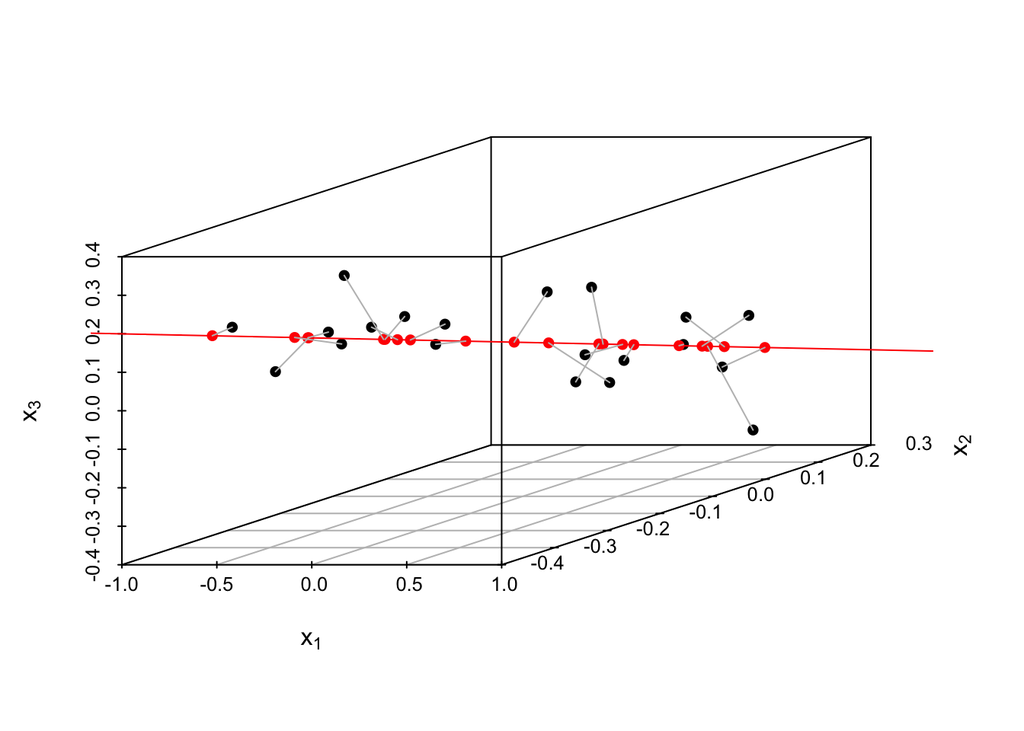

1. Calcolare la matrice di varianze/covarianze $\Sigma = \Lambda \Lambda' + \Psi$ e confrontarla con la sua stima $S$ ottenuta dalla matrice dei dati $X$

```r
Sigma = Lambda %*% t(Lambda) + Psi
Sigma
```

```
        [,1]    [,2]   [,3]
[1,]  0.2725  0.1000 -0.050
[2,]  0.1000  0.0425 -0.020
[3,] -0.0500 -0.0200  0.018
```

```r
S = var(X) * ((n-1)/n)
round(S,2)
```

```
      [,1]  [,2]  [,3]
[1,]  0.18  0.06 -0.04
[2,]  0.06  0.03 -0.02
[3,] -0.04 -0.02  0.02
```

2. Per ciascuna osservazione $x$, si considerari la trasformazione di scala $z = A x$ per $A=D^{-1/2}$ dove $D = diag(\Sigma)$, ottenendo la matrice dei dati trasformati $Y = XA$.
- Calcolare i pesi fattoriali $\Lambda_y = A \Lambda$ e le varianze specifiche $\Psi_y = A \Psi A'$
- Calcolare la matrice di correlazione $\mathbb{C}\mathrm{ov}(z) = \mathbb{C}\mathrm{orr}(x)=D^{-1/2}\Sigma D^{-1/2}$ e confrontarla con la sua stima $R$ ottenuta dalla matrice dei dati $X$

```r
A = diag(diag(Sigma)^(-1/2))
Y = X %*% A
Lambday = A %*% Lambda
Psiy = A %*% Psi %*% t(A)
# varianze specifiche di y
diag(Psiy)
```

```
[1] 0.08256881 0.05882353 0.44444444
```

```r
Corrx = A %*% Sigma %*% t(A)
round(Corrx,2)
```

```
      [,1]  [,2]  [,3]
[1,]  1.00  0.93 -0.71
[2,]  0.93  1.00 -0.72
[3,] -0.71 -0.72  1.00
```

```r
Sy = var(Y) *((n-1)/n)
round(Sy,2)
```

```
      [,1]  [,2]  [,3]
[1,]  0.68  0.57 -0.58
[2,]  0.57  0.60 -0.56
[3,] -0.58 -0.56  0.96
```

```r
R = cor(X)
round(R,2)
```

```
      [,1]  [,2]  [,3]
[1,]  1.00  0.90 -0.72
[2,]  0.90  1.00 -0.73
[3,] -0.72 -0.73  1.00
```

3. Stimare con il metodo della massima verosimiglianza il modello fattoriale con $k=1$ fattore (funzione `factanal()`, argomenti `factors=1` e `rotation="none"`), ed ottenere
- la stima della matrice dei pesi fattoriali $\hat{\Lambda}$;
- la stima delle comunalità $\hat{h}^2_i$;
- la stima delle varianze specifiche $\hat{\psi}_i$;

```r
af <- factanal(x=X, factors=1, rotation="none")
af
```

```
Call:
factanal(x = X, factors = 1, rotation = "none")

Uniquenesses:
[1] 0.122 0.082 0.415

Loadings:
     Factor1
[1,]  0.937
[2,]  0.958
[3,] -0.765

               Factor1
SS loadings      2.381
Proportion Var   0.794

The degrees of freedom for the model is 0 and the fit was 0
```

```r
# stima dei pesi fattoriali
hatLambda <- af$loadings[,]
round(hatLambda,3)
```

```
[1]  0.937  0.958 -0.765
```

```r
# stima delle comunalità
hatH2 <- apply(af$loadings^2,1,sum)
round(hatH2,3)
```

```
[1] 0.878 0.918 0.585
```

```r
# stima delle varianze specifiche
hatPsi <- diag(af$uniquenesses)
round(diag(hatPsi),3)
```

```
[1] 0.122 0.082 0.415
```

```r
# differenza
R - ( hatLambda%*%t(hatLambda) + hatPsi )
```

```
              [,1]         [,2]          [,3]
[1,] -4.121273e-07 1.060492e-07 -1.053887e-06
[2,]  1.060492e-07 1.028022e-07  1.093042e-06
[3,] -1.053887e-06 1.093042e-06  2.497108e-06
```

# Dati Esami

Si consideri la seguente matrice di correlazione

```r
rm(list=ls())
R = matrix(c(
 1.000, 0.439, 0.410, 0.288, 0.329, 0.248,
 0.439, 1.000, 0.351, 0.354, 0.320, 0.329,
 0.410, 0.351, 1.000, 0.164, 0.190, 0.181,
 0.288, 0.354, 0.164, 1.000, 0.595, 0.470,
 0.329, 0.320, 0.190, 0.595, 1.000, 0.464,
 0.248, 0.329, 0.181, 0.470, 0.464, 1.000
), byrow=T, ncol=6)
colnames(R) = c("Gaelic", "English", "History", "Arithmetic", "Algebra", "Geometry")
R
```

```
     Gaelic English History Arithmetic Algebra Geometry
[1,]  1.000   0.439   0.410      0.288   0.329    0.248
[2,]  0.439   1.000   0.351      0.354   0.320    0.329
[3,]  0.410   0.351   1.000      0.164   0.190    0.181
[4,]  0.288   0.354   0.164      1.000   0.595    0.470
[5,]  0.329   0.320   0.190      0.595   1.000    0.464
[6,]  0.248   0.329   0.181      0.470   0.464    1.000
```

relativa ai voti di $n=220$ studenti maschi nelle materie *Gaelic*, *English*, *History*, *Arithmetic*, *Algebra* e *Geometry* ($p=6$). Interpretare la matrice di correlazione.

I voti tra le materie sono correlati positivamente, ovvero gli studenti che vanno bene in una specifica materia vanno bene anche nelle altre. Le correlazioni più forti si trovano nel gruppo delle materie matematiche, e in misura leggermente inferiore, nel gruppo delle materie umanistiche, mentre c’è meno correlazione tra i due gruppi di materie.

1. Stimare con il metodo della massima verosimiglianza il modello fattoriale con $k=2$ fattori (funzione `factanal()`, argomenti `factors=2` e `rotation="none"`), ottenendo la stima della matrice dei pesi fattoriali, interpretando i due fattori ottenuti;

```r
n = 220
# modello fattoriale con 2 fattori senza rotazione
af <- factanal(covmat=R, factors=2, rotation="none", n.obs=n)
af
```

```
Call:
factanal(factors = 2, covmat = R, n.obs = n, rotation = "none")

Uniquenesses:
    Gaelic    English    History Arithmetic    Algebra   Geometry
     0.510      0.594      0.644      0.377      0.431      0.628

Loadings:
     Factor1 Factor2
[1,]  0.553   0.429
[2,]  0.568   0.288
[3,]  0.392   0.450
[4,]  0.740  -0.273
[5,]  0.724  -0.211
[6,]  0.595  -0.132

               Factor1 Factor2
SS loadings      2.209   0.606
Proportion Var   0.368   0.101
Cumulative Var   0.368   0.469

Test of the hypothesis that 2 factors are sufficient.
The chi square statistic is 2.33 on 4 degrees of freedom.
The p-value is 0.674
```

```r
# stima dei pesi fattoriali
Lambda <- af$loadings[,]
round(Lambda,3)
```

```
     Factor1 Factor2
[1,]   0.553   0.429
[2,]   0.568   0.288
[3,]   0.392   0.450
[4,]   0.740  -0.273
[5,]   0.724  -0.211
[6,]   0.595  -0.132
```

```r
# primo fattore "andare bene a scuola"
# secondo fattore "math vs non-math"
```

2. Stimare il modello fattoriale con $k=2$ fattori eseguendo la rotazione `varimax` della matrice dei pesi fattoriali (argomento `rotation="varimax"`). Confrontare le stime delle varianze specifiche e della matrice dei pesi fattoriali con la soluzione senza rotazione.

```r
# rotazione varimax
af2 <- factanal(covmat = R, factors=2, rotation="varimax", n.obs=n)
af2
```

```
Call:
factanal(factors = 2, covmat = R, n.obs = n, rotation = "varimax")

Uniquenesses:
    Gaelic    English    History Arithmetic    Algebra   Geometry
     0.510      0.594      0.644      0.377      0.431      0.628

Loadings:
     Factor1 Factor2
[1,] 0.235   0.659
[2,] 0.323   0.549
[3,]         0.590
[4,] 0.771   0.170
[5,] 0.724   0.213
[6,] 0.572   0.210

               Factor1 Factor2
SS loadings      1.612   1.203
Proportion Var   0.269   0.201
Cumulative Var   0.269   0.469

Test of the hypothesis that 2 factors are sufficient.
The chi square statistic is 2.33 on 4 degrees of freedom.
The p-value is 0.674
```

```r
# matrice di rotazione
af2$rotmat
```

```
           [,1]      [,2]
[1,]  0.8420397 0.5394156
[2,] -0.5394156 0.8420397
```

```r
# la matrice dei pesi fattoriali cambia
af2$loadings
```

```
Loadings:
     Factor1 Factor2
[1,] 0.235   0.659
[2,] 0.323   0.549
[3,]         0.590
[4,] 0.771   0.170
[5,] 0.724   0.213
[6,] 0.572   0.210

               Factor1 Factor2
SS loadings      1.612   1.203
Proportion Var   0.269   0.201
Cumulative Var   0.269   0.469
```

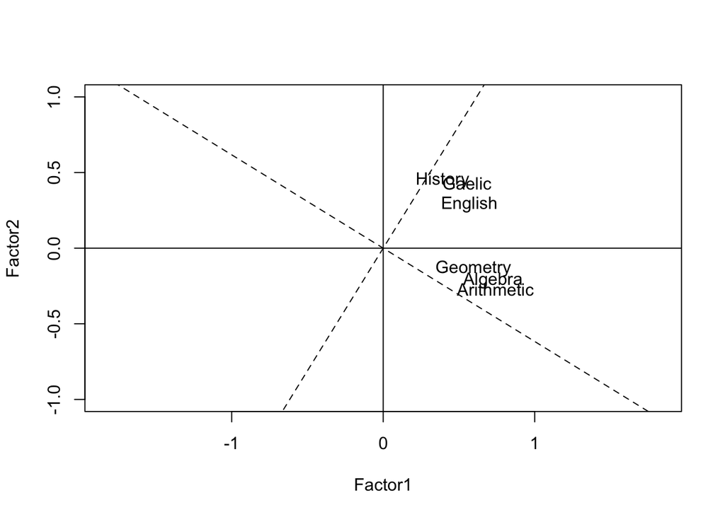

```r
# primo fattore "math"
# secondo fattore "non-math"

# rappresentazione grafica della rotazione
plot(af$loadings,xlim=c(-1,1), ylim=c(-1,1), pch="", asp=1)
text(af$loadings, colnames(R))
abline(h=0)
abline(v=0)
af2 <- varimax(af$loadings,normalize=FALSE)
abline(0, af2$rotmat[2,1]/af2$rotmat[1,1], lty=2)
abline(0, af2$rotmat[2,2]/af2$rotmat[1,2], lty=2)
```

3. Si riporti il $p$-value del test rapporto di verosimiglianza per verificare l’ipotesi nulla $H_0:$ `$k=1$ fattore è sufficiente’, e si concluda ad un livello di significatività del $5\%$ se è opportuno utilizzare il modello fattoriale ad 1 fattore.

```r
factanal(covmat=R, factors=1, n.obs = n)$PVAL
```

```
   objective
4.528823e-08
```

4. Si calcoli la statistica test rapporto di verosimiglianza
   $$T= n \log (|\hat{\Lambda} \hat{\Lambda}' + \hat{\Psi}|/|R|)$$
   e il corrispondente $p$-value.

```r
k=1
p=6
af = factanal(covmat=R, factors=k, n.obs = n)
hatLambda = af$loadings[,]
hatPsi = diag(af$uniqueness)
fit = hatLambda %*% t(hatLambda) + hatPsi
t = n*log(det(fit)/det(R))
t
```

```
[1] 53.08106
```

```r
gdl = ((p-k)^2 - p - k)/2
pchisq(t, lower.tail=FALSE, df=gdl)
```

```
[1] 2.821254e-08
```

# Dati Open/Closed Book Examination Data

Caricare il dati `scor` presenti nella libreria `bootstrap` e calcolare la matrice di correlazione $\underset{p\times p}{R}$.

```r
library(bootstrap)

# carico i dati:
data(scor)
X <- scor
n <- nrow(X)
p <- ncol(X)

# matrice di correlazione
R <- cor(X)
round(R, 2)
```

```
     mec  vec  alg  ana  sta
mec 1.00 0.55 0.55 0.41 0.39
vec 0.55 1.00 0.61 0.49 0.44
alg 0.55 0.61 1.00 0.71 0.66
ana 0.41 0.49 0.71 1.00 0.61
sta 0.39 0.44 0.66 0.61 1.00
```

1. Utilizzando la funzione `factanal()`, stimare con il metodo della massima verosimiglianza il modello fattoriale con $k=2$ fattori (argomento `factors=2`) eseguendo la rotazione `varimax` della matrice dei pesi fattoriali (argomento `rotation="varimax"`).  
   Stimare i punteggi fattoriali con il metodo di Thompson e rappresentarli graficamente.

```r
af <- factanal(X, factors=2, rotation = "varimax", scores="regression")
af$loadings
```

```
Loadings:
    Factor1 Factor2
mec 0.265   0.681
vec 0.356   0.674
alg 0.740   0.514
ana 0.738   0.322
sta 0.696   0.290

               Factor1 Factor2
SS loadings      1.774   1.370
Proportion Var   0.355   0.274
Cumulative Var   0.355   0.629
```

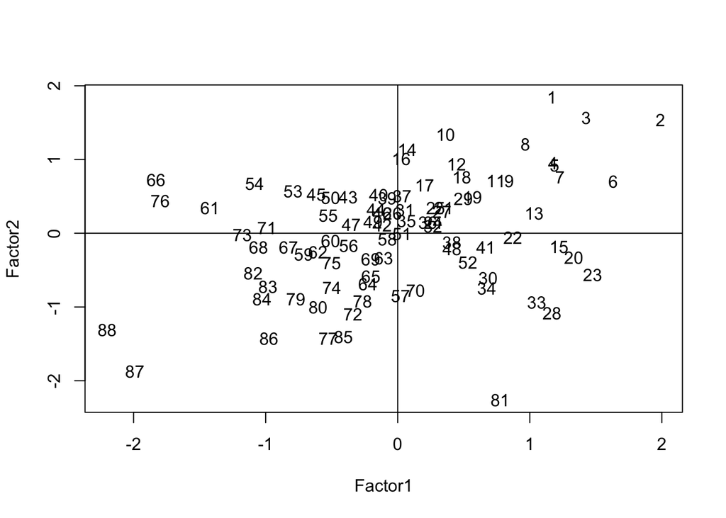

```r
# primo fattore "open book"
# secondo fattore "closed book"
puntfat <- af$scores
# punteggi fattoriali con il metodo di thompson
plot(puntfat,pch="")
text(puntfat, labels=c(1:88))
abline(h=0)
abline(v=0)
```

```r
# studente 66
X[66,]
```

```
   mec vec alg ana sta
66  59  53  37  22  19
```

2. Calcolare la stima iniziale delle comunalità $\hat{h}^2_i$ come
   $$\hat{h}^2_i = \max_{j\neq i}|r_{ij}|$$
   per $i=1,\ldots,p$, dove $r_{ij}$ è l’elemento di posizione $(i,j)$ della matrice $R$. Ottenere la matrice di correlazione ridotta
   $$R^*= R - \hat{\Psi}$$
   dove $\hat{\Psi} = diag(\hat{\psi}_1,\ldots,\hat{\psi}_p)$ con $\hat{\psi}_i = 1 - \hat{h}^2_i$.

```r
# sostituisco 1 sulla diagonale di R con 0
R0 <- R - diag(rep(1,p))
# calcolo la stima iniziale della comunalità
h2 <- apply(abs(R0), 2, max)
h2
```

```
      mec       vec       alg       ana       sta
0.5534052 0.6096447 0.7108059 0.7108059 0.6647357
```

```r
# calcolo la stima di Psi
Psi = diag(1-h2)
Psi
```

```
          [,1]      [,2]      [,3]      [,4]      [,5]
[1,] 0.4465948 0.0000000 0.0000000 0.0000000 0.0000000
[2,] 0.0000000 0.3903553 0.0000000 0.0000000 0.0000000
[3,] 0.0000000 0.0000000 0.2891941 0.0000000 0.0000000
[4,] 0.0000000 0.0000000 0.0000000 0.2891941 0.0000000
[5,] 0.0000000 0.0000000 0.0000000 0.0000000 0.3352643
```

```r
# calcolo la matrice di correlazione ridotta R*
Rstar <- R - Psi
round(Rstar,2)
```

```
     mec  vec  alg  ana  sta
mec 0.55 0.55 0.55 0.41 0.39
vec 0.55 0.61 0.61 0.49 0.44
alg 0.55 0.61 0.71 0.71 0.66
ana 0.41 0.49 0.71 0.71 0.61
sta 0.39 0.44 0.66 0.61 0.66
```

3. Considerando il modello fattoriale con $k=2$ fattori
- calcolare la stima della matrice dei pesi fattoriali
  $$\hat{\Lambda} = V_k L^{1/2}_k$$
  dopo aver ottenuto la decomposizione spettrale di $R^* = V L V'$ e dove $\underset{p \times k}{V_k}$ contiene le prime $k$ colonne di $V$ e $\underset{k \times k}{L_k} = diag(l_1,\ldots,l_k)$.
- aggiornare la stima delle comunalità
  $$\hat{h}^2_i = \sum_{j=1}^{k} \hat{\lambda}^2_{ij}$$
  dove $\hat{\lambda}_{ij}$ è l’elemento di posizione $(i,j)$ della matrice $\hat{\Lambda}$ ottenuta al passo precedente
- aggiornare la stima della matrice di correlazione ridotta
  $$R^*= R - \hat{\Psi}$$
  dove $\hat{\Psi} = diag(\hat{\psi}_1,\ldots,\hat{\psi}_p)$ con $\hat{\psi}_i = 1 - \hat{h}^2_i$ dove $\hat{h}^2_i$ è la stima ottenuta al passo precedente

```r
# decomposizione spettrale di R*
eigen <- eigen(Rstar)

#  k=2
k = 2

# stima di Lambda
Lambda <- eigen$vectors[,1:k] %*% diag(eigen$values[1:k]^{1/2})
Lambda
```

```
           [,1]        [,2]
[1,] -0.6459890  0.35354561
[2,] -0.7125528  0.30300833
[3,] -0.8639382 -0.05134392
[4,] -0.7864129 -0.24856797
[5,] -0.7419269 -0.27558100
```

```r
# nuova stima comunalità
h2.new = apply(Lambda^2, 1, sum)
h2.new
```

```
[1] 0.5422963 0.5995455 0.7490254 0.6802313 0.6264004
```

```r
# nuova stima di Psi
Psi.new <- diag(1-h2.new)
Psi.new
```

```
          [,1]      [,2]      [,3]      [,4]      [,5]
[1,] 0.4577037 0.0000000 0.0000000 0.0000000 0.0000000
[2,] 0.0000000 0.4004545 0.0000000 0.0000000 0.0000000
[3,] 0.0000000 0.0000000 0.2509746 0.0000000 0.0000000
[4,] 0.0000000 0.0000000 0.0000000 0.3197687 0.0000000
[5,] 0.0000000 0.0000000 0.0000000 0.0000000 0.3735996
```

```r
# nuova stima di R*
Rstar.new = R - Psi.new
Rstar.new
```

```
          mec       vec       alg       ana       sta
mec 0.5422963 0.5534052 0.5467511 0.4093920 0.3890993
vec 0.5534052 0.5995455 0.6096447 0.4850813 0.4364487
alg 0.5467511 0.6096447 0.7490254 0.7108059 0.6647357
ana 0.4093920 0.4850813 0.7108059 0.6802313 0.6071743
sta 0.3890993 0.4364487 0.6647357 0.6071743 0.6264004
```

4. Iterare per 100 volte la procedura descritta al punto 3, ottenendo le stime finali per $\hat{\Lambda}$ e $\hat{\Psi}$. Calcolare la differenza tra $R$ e $\hat{\Lambda} \hat{\Lambda}' + \hat{\Psi}$ e commentare.

```r
for (i in 1:100){
  h2 <- apply(Lambda^2, 1, sum)
  Rstar <- R0 + diag(h2)
  eigen <- eigen(Rstar)
  Lambda <- eigen$vectors[,1:k] %*% diag(eigen$values[1:k]^{1/2})
}

# stima finale per Lambda
Lambda
```

```
           [,1]        [,2]
[1,] -0.6427483  0.34238878
[2,] -0.7081925  0.28687387
[3,] -0.8966056 -0.08718706
[4,] -0.7710248 -0.23504626
[5,] -0.7179803 -0.22818566
```

```r
# stima finale per le comunalità
h2 <- apply(Lambda^2, 1, sum)
h2
```

```
[1] 0.5303554 0.5838332 0.8115032 0.6497260 0.5675644
```

```r
# stima finale per Psi
Psi = diag(1-h2)

# differenza
fit = Lambda%*%t(Lambda) + Psi
round( R - fit, 4)
```

```
        mec     vec     alg     ana     sta
mec  0.0000  0.0000  0.0003 -0.0057  0.0057
vec  0.0000  0.0000 -0.0003  0.0065 -0.0066
alg  0.0003 -0.0003  0.0000 -0.0010  0.0011
ana -0.0057  0.0065 -0.0010  0.0000  0.0000
sta  0.0057 -0.0066  0.0011  0.0000  0.0000
```

# Speranza di vita

I dati nella seguente Tabella mostrano l’aspettativa di vita in anni per paese, età e sesso. I dati provengono da Key Tz e Flieger (1971) e riguardano le aspettative di vita negli anni ’60.

Per importare i dati:

```r
"life" <-
  structure(.Data = list(c(63., 34., 38., 59., 56., 62., 50., 65., 56., 69., 65., 64., 56., 60., 61., 49., 59., 63., 59., 65., 65., 64.,
                           64., 67., 61., 68., 67., 65., 59., 58., 57.)
                         , c(51., 29., 30., 42., 38., 44., 39., 44., 46., 47., 48., 50., 44., 44., 45., 40., 42., 44., 44., 48., 48., 63.,
                             43., 45., 40., 46., 45., 46., 43., 44., 46.)
                         , c(30., 13., 17., 20., 18., 24., 20., 22., 24., 24., 26., 28., 25., 22., 22., 22., 22., 23., 24., 28., 26., 21.,
                             21., 23., 21., 23., 23., 24., 23., 24., 28.)
                         , c(13., 5., 7., 6., 7., 7., 7., 7., 11., 8., 9., 11., 10., 6., 8., 9., 6., 8., 8., 14., 9., 7., 6., 8., 10., 8.,
                             8., 9., 10., 9., 9.)
                         , c(67., 38., 38., 64., 62., 69., 55., 72., 63., 75., 68., 66., 61., 65., 65., 51., 61., 67., 63., 68., 67., 68.,
                             68., 74., 67., 75., 74., 71., 66., 62., 60.)
                         , c(54., 32., 34., 46., 46., 50., 43., 50., 54., 53., 50., 51., 48., 45., 49., 41., 43., 48., 46., 51., 49., 47.,
                             47., 51., 46., 52., 51., 51., 49., 47., 49.)
                         , c(34., 17., 20., 25., 25., 28., 23., 27., 33., 29., 27., 29., 27., 25., 27., 23., 22., 26., 25., 29., 27., 25.,
                             24., 28., 25., 29., 28., 28., 27., 25., 28.)
                         , c(15., 6., 7., 8., 10., 14., 8., 9., 19., 10., 10., 11., 12., 9., 10., 8., 7., 9., 8., 13., 10., 9., 8., 10., 11.,
                             10., 10., 10., 12., 10., 11.)
  )
  , class = "data.frame"
  , names = c("m0", "m25", "m50", "m75", "w0", "w25", "w50", "w75")
  , row.names = c("Algeria", "Cameroon", "Madagascar", "Mauritius", "Reunion", "Seychelles", "South Africa(C)", "South Africa(W)",
                  "Tunisia", "Canada", "Costa Rica", "Dominican Rep", "El Salvador", "Greenland", "Grenada", "Guatemala",
                  "Honduras", "Jamaica", "Mexico", "Nicaragua", "Panama", "Trinidad(62)", "Trinidad (67)",
                  "United States (66)", "United States (NW66)", "United States (W66)", "United States (67)", "Argentina",
                  "Chile", "Columbia", "Ecuador")
  )
knitr::kable(life, "html")
```

[output not shown]

1. Per iniziare, useremo il test per il numero di fattori incorporati nell’approccio alla massima verosimiglianza

```r
round(sapply(1:3, function(f)
factanal(life, factors = f, method ="mle")$PVAL
),4)
```

```
objective objective objective
   0.0000    0.0000    0.4578
```

Questi risultati suggeriscono che una soluzione a tre fattori potrebbe essere adeguata per tenere conto per le covarianze osservate nei dati, sebbene debba essere ricordato che, con solo 31 paesi, l’uso di un risultato del test asintotico potrebbe essere piuttosto sospetto.

La soluzione a tre fattori è la seguente (notare che la soluzione è quella risultante da una soluzione varimax. il valore predefinito per la funzione factanal()):

```r
factanal(life, factors = 3, method ="mle")
```

```
Call:
factanal(x = life, factors = 3, method = "mle")

Uniquenesses:
   m0   m25   m50   m75    w0   w25   w50   w75
0.005 0.362 0.066 0.288 0.005 0.011 0.020 0.146

Loadings:
    Factor1 Factor2 Factor3
m0  0.964   0.122   0.226
m25 0.646   0.169   0.438
m50 0.430   0.354   0.790
m75         0.525   0.656
w0  0.970   0.217
w25 0.764   0.556   0.310
w50 0.536   0.729   0.401
w75 0.156   0.867   0.280

               Factor1 Factor2 Factor3
SS loadings      3.375   2.082   1.640
Proportion Var   0.422   0.260   0.205
Cumulative Var   0.422   0.682   0.887

Test of the hypothesis that 3 factors are sufficient.
The chi square statistic is 6.73 on 7 degrees of freedom.
The p-value is 0.458
```

Esaminando i pesi stimati dei fattori, vediamo che

- il primo fattore è dominato dall’aspettativa di vita alla nascita (sia maschi che femmine); potrebbe essere etichettato *forza vitale alla nascita*
- il secondo fattore secondo fattore misura sostanzialmente l’aspettativa di vita per le donne anziane; potrebbe essere etichettato *forza vitale per le donne anziane*
- il terzo fattore ha pesi più elevati per le aspettative di vita degli uomini di età compresa tra 50 e 75 anni: potrebbe essere etichettato *forza vitale per gli uomini anziani*

Le stime dei punteggi fattoriali secondo il metodo di Thomson sono

```r
scores <- factanal(life, factors = 3, method = "mle", scores = "regression")$scores
scores
```

```
                          Factor1     Factor2     Factor3
Algeria              -0.258062561  1.90095771  1.91581631
Cameroon             -2.782495791 -0.72340014 -1.84772224
Madagascar           -2.806428187 -0.81158820 -0.01210318
Mauritius             0.141004934 -0.29028454 -0.85862443
Reunion              -0.196352142  0.47429917 -1.55046466
Seychelles            0.367371307  0.82902375 -0.55214085
South Africa(C)      -1.028567629 -0.08065792 -0.65421971
South Africa(W)       0.946193522  0.06400408 -0.91995289
Tunisia              -0.862493550  3.59177195 -0.36442148
Canada                1.245304248  0.29564122 -0.27342781
Costa Rica            0.508736247 -0.50500435  1.01328707
Dominican Rep         0.106044085  0.01111171  1.83871599
El Salvador          -0.608155779  0.65100820  0.48836431
Greenland             0.235114220 -0.69123901 -0.38558654
Grenada               0.132008172  0.25241049 -0.15220645
Guatemala            -1.450336359 -0.67765804  0.65911906
Honduras              0.043253249 -1.85175707  0.30633182
Jamaica               0.462124701 -0.51918493  0.08032855
Mexico               -0.052332675 -0.72020002  0.44417800
Nicaragua             0.268974443  0.08407227  1.70568388
Panama                0.442333434 -0.73778272  1.25218728
Trinidad(62)          0.711367053 -0.95989475 -0.21545329
Trinidad (67)         0.787286051 -1.10729029 -0.51958264
United States (66)    1.128331259  0.16389896 -0.68177046
United States (NW66)  0.400058903 -0.36230253 -0.74299137
United States (W66)   1.214345385  0.40877239 -0.69225320
United States (67)    1.128331259  0.16389896 -0.68177046
Argentina             0.731344988  0.24811968 -0.12817725
Chile                 0.009751528  0.75222637 -0.49198911
Columbia             -0.240602517 -0.29543613  0.42919600
Ecuador              -0.723451797  0.44246371  1.59164974
```

Possiamo usare i punteggi per interpretare i dati

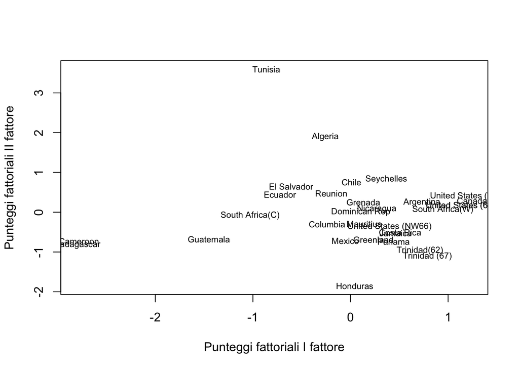

```r
plot(scores[,1], scores[,2], type='n', xlab='Punteggi fattoriali I fattore', ylab='Punteggi fattoriali II fattore')
text(scores[,1], scores[,2], labels = row.names(life), cex = 0.7 )
```

Vediamo che il Madagascar e il Camerun hanno i valori più bassi per il primo fattore, mentre gli Stati Uniti e il Canada hanno valori elevati.

Il secondo fattore misura sostanzialmente l’aspettativa di vita per le donne anziane. Tunisia ha un punteggio elevato, mentre Honduras basso per questo fattore.

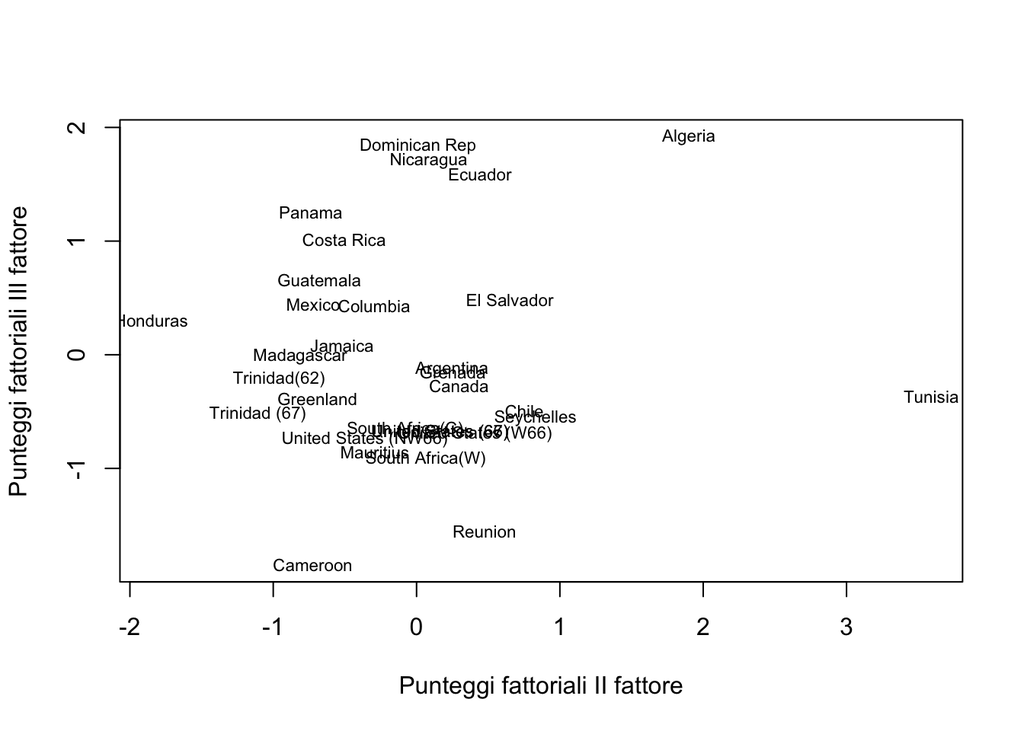

```r
plot(scores[,2], scores[,3], type='n', xlab='Punteggi fattoriali II fattore', ylab='Punteggi fattoriali III fattore')
text(scores[,2], scores[,3], labels = row.names(life), cex = 0.7 )
```

Il terzo fattore riflette (principalmente) l’aspettativa di vita per gli uomini più anziani. Il Camerun ha il punteggio più basso per questo fattore, mentre L’Algeria ha il punteggio più alto.